# R Notebook

### Import data from Coles et al. (2022), filter study 1 which was in the laboratory and only include subjects from the no-hypothesis group (aka ‘Control’). Reduce and convert the dataframe into long format.

```r
DF.long <- readRDS("./Coles/data/clean/data.long.clean.rds")
DF.wide <- readRDS("./Coles/data/clean/data.wide.clean.rds")

DF.long$trial <- factor(DF.long$trial, levels = c('Anger', 'Neutral', 'Happy'))

DF.long$pose <- as.numeric(DF.long$trial)
DF.long$ResponseId <- as.numeric(DF.long$ResponseId)
DF.long$block.num <- as.numeric(DF.long$block.num)

df <-
  filter(DF.long, study == 'Study_1' & demand == 'Control') %>%
  select(ResponseId, pose, happy, anger, trialnum = block.num) %>%
  mutate(anger = anger * (-1)) %>%
  pivot_longer(cols = c('happy', 'anger'),
               names_to = "emo", values_to = "rating")
```

### Print sample size and plot DVs from Coles et al., 2022

```r
# n participants who met inclusion criteria
df$ResponseId %>% unique() %>% length()
```

```
## [1] 77
```

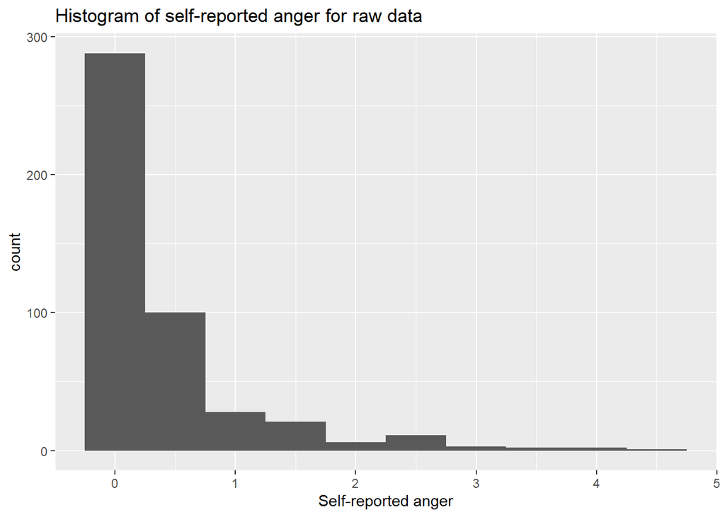

```r
filter(DF.long, study == 'Study_1' & demand == 'Control') %>%
  ggplot(., aes(x = anger))+
  geom_histogram(binwidth = .5)+
  labs(title = 'Histogram of self-reported anger for raw data',
       x = 'Self-reported anger')
```

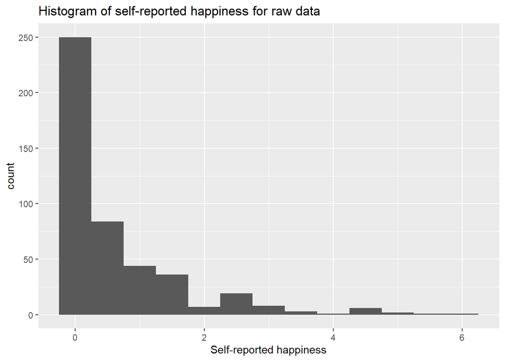

```r
filter(DF.long, study == 'Study_1' & demand == 'Control') %>%
  ggplot(., aes(x = happy))+
  geom_histogram(binwidth = .5) +
  labs(title = 'Histogram of self-reported happiness for raw data',
       x = 'Self-reported happiness')
```

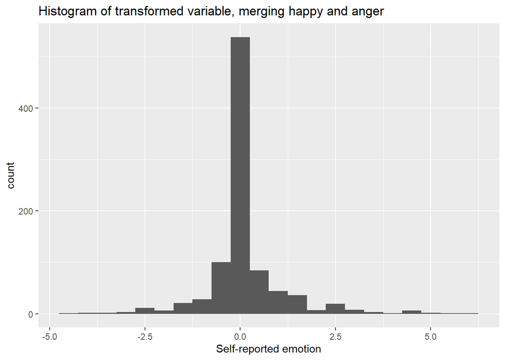

```r
ggplot(df, aes(x = rating))+
  geom_histogram(binwidth = .5) +
  labs(title = 'Histogram of transformed variable, merging happy and anger',
       x = 'Self-reported emotion')
```

### Run the model

```r
m <- df %>%
  lmerTest::lmer(rating ~ pose +
                      ( 1 | ResponseId), data = .)
summary(m)
```

```
## Linear mixed model fit by REML. t-tests use Satterthwaite's method [
## lmerModLmerTest]
## Formula: rating ~ pose + (1 | ResponseId)
##    Data: .
##
## REML criterion at convergence: 2550
##
## Scaled residuals:
##    Min     1Q Median     3Q    Max
## -4.679 -0.480 -0.090  0.311  5.662
##
## Random effects:
##  Groups     Name        Variance Std.Dev.
##  ResponseId (Intercept) 0.0389   0.197
##  Residual               0.8854   0.941
## Number of obs: 924, groups:  ResponseId, 77
##
## Fixed effects:
##             Estimate Std. Error       df t value             Pr(>|t|)
## (Intercept)  -0.6245     0.0849 773.5636   -7.35      0.0000000000005 ***
## pose          0.3766     0.0379 846.0000    9.93 < 0.0000000000000002 ***
## ---
## Signif. codes:  0 '***' 0.001 '**' 0.01 '*' 0.05 '.' 0.1 ' ' 1
##
## Correlation of Fixed Effects:
##      (Intr)
## pose -0.893
```

```r
broom.mixed::tidy(m)
```

| effect | group | term | estimate | std.error | statistic | df | p.value |
| --- | --- | --- | --- | --- | --- | --- | --- |
| fixed | NA | (Intercept) | -0.62 | 0.085 | -7.4 | 774 | 0.00000000000049565315875 |
| fixed | NA | pose | 0.38 | 0.038 | 9.9 | 846 | 0.00000000000000000000045 |
| ran_pars | ResponseId | sd__(Intercept) | 0.20 | NA | NA | NA | NA |
| ran_pars | Residual | sd__Observation | 0.94 | NA | NA | NA | NA |

### The model output shows an intercept of -.62 and fixed effect of pose as .38. Lets half this to .19

### Here we plot our simulations, pose is the orignal beta (.38) and pose1 is the SESOI (.19) we chose. This is also reflected in the column ‘mode’ database being from the given dataset and SESOI being defined by us.

|  | 40 | 50 | 60 | mode | effect |
| --- | --- | --- | --- | --- | --- |
| pose | 1.00 | 1.00 | 1.00 | databased | pose |
| pose1 | 0.96 | 0.99 | 0.99 | SESOI | pose |

### Lets set it to .09 which is 1/4 of Coles beta

|  | 120 | 140 | mode | effect |
| --- | --- | --- | --- | --- |
| pose | 1.00 | 1.0 | databased | pose |
| pose1 | 0.83 | 0.9 | SESOI | pose |

### Lets re-run the model standaridised

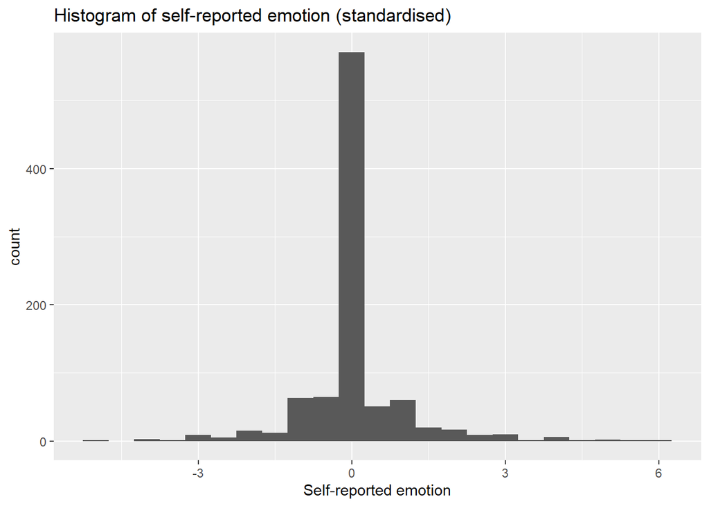

```r
df$rating_c <- scale(df$rating, center = T, scale = T)
df$pose_c <- scale(df$pose, center = T, scale = T)

ggplot(df, aes(x = rating_c)) +
  geom_histogram(binwidth = 0.5) +
     labs(title = 'Histogram of self-reported emotion (standardised)',
          x = 'Self-reported emotion')
```

```r
m <- df %>%
  lmerTest::lmer(rating_c ~ pose_c +
                      ( 1 | ResponseId), data = .)
broom.mixed::tidy(m)
```

| effect | group | term | estimate | std.error | statistic | df | p.value |
| --- | --- | --- | --- | --- | --- | --- | --- |
| fixed | NA | (Intercept) | -0.000000000000000017 | 0.038 | -0.00000000000000046 | 76 | 0.99999999999999955591079 |
| fixed | NA | pose_c | 0.305008327985863748 | 0.031 | 9.93389478025350670 | 846 | 0.00000000000000000000045 |
| ran_pars | ResponseId | sd__(Intercept) | 0.195536744963103554 | NA | NA | NA | NA |
| ran_pars | Residual | sd__Observation | 0.932809568724089599 | NA | NA | NA | NA |

### Now our intercept is 0 and the effect of pose is .3. Lets simulate with .1

|  | 65 | 70 | 75 | 80 | mode | effect |
| --- | --- | --- | --- | --- | --- | --- |
| pose_c | 1.00 | 1.00 | 1.00 | 1.0 | databased | pose_c |
| pose_c1 | 0.84 | 0.83 | 0.88 | 0.9 | SESOI | pose_c |

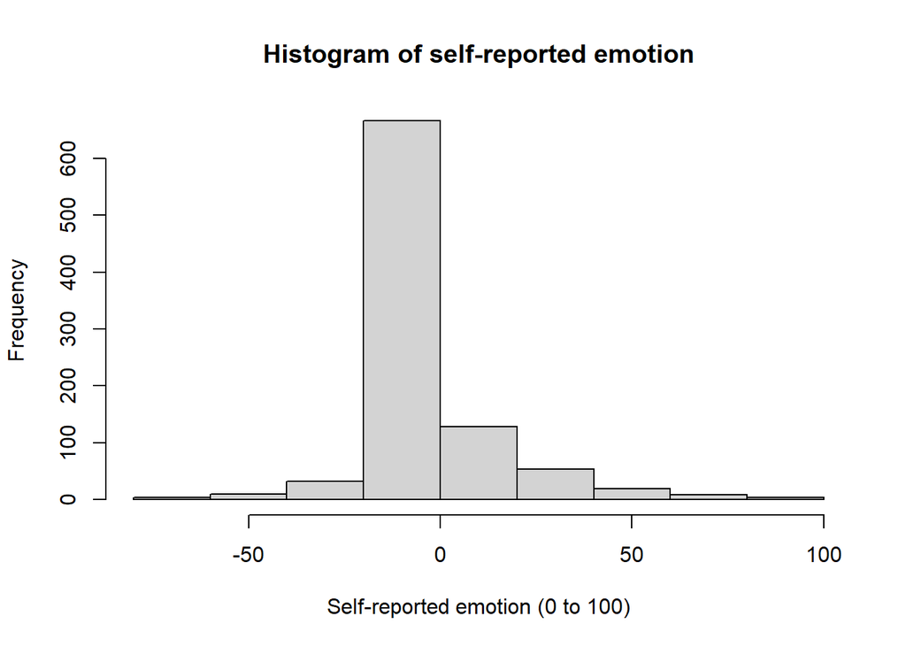

```r
df <-
  filter(DF.long, study == 'Study_1' & demand == 'Control') %>%
  select(ResponseId, pose, trialnum = block.num, happy, anger) %>%
  mutate(happy = happy / 6 * 100,
         anger = anger / 6 * 100) %>%
  mutate(anger = anger * (-1)) %>%
  pivot_longer(cols = c('happy', 'anger'),
               names_to = "emo", values_to = "rating")

hist(df$rating,
     main = 'Histogram of self-reported emotion',
     xlab = 'Self-reported emotion (0 to 100)')
```

### Run the model

```r
m <- df %>%
  lmerTest::lmer(rating ~ pose +
                      ( 1 | ResponseId), data = .)
broom.mixed::tidy(m)
```

| effect | group | term | estimate | std.error | statistic | df | p.value |
| --- | --- | --- | --- | --- | --- | --- | --- |
| fixed | NA | (Intercept) | -10.4 | 1.42 | -7.4 | 774 | 0.00000000000049565315695 |
| fixed | NA | pose | 6.3 | 0.63 | 9.9 | 846 | 0.00000000000000000000045 |
| ran_pars | ResponseId | sd__(Intercept) | 3.3 | NA | NA | NA | NA |
| ran_pars | Residual | sd__Observation | 15.7 | NA | NA | NA | NA |

### Simulate using unstandardised -100 to 100 ratings, the intercept is -10.4 and the effect of pose is 6.3. Lets take 2 for the simulation of SESOI

|  | 65 | 70 | 75 | 80 | 85 | 90 | mode | effect |
| --- | --- | --- | --- | --- | --- | --- | --- | --- |
| pose | 1.00 | 1.00 | 1.00 | 1.00 | 1.00 | 1.00 | databased | pose |
| pose1 | 0.82 | 0.85 | 0.87 | 0.89 | 0.92 | 0.93 | SESOI | pose |

### Do the same as above but on standardised data

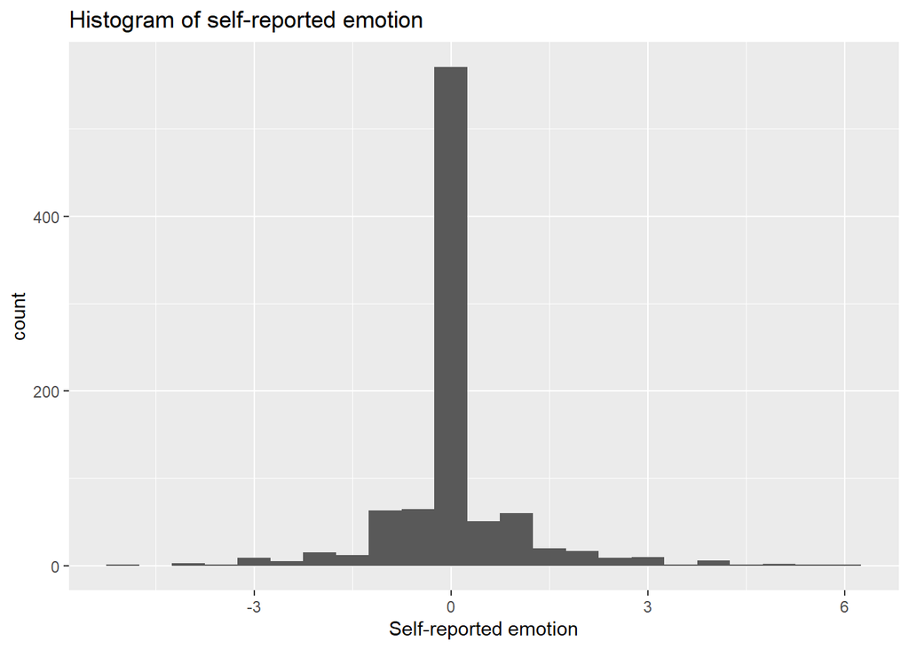

| effect | group | term | estimate | std.error | statistic | df | p.value |
| --- | --- | --- | --- | --- | --- | --- | --- |
| fixed | NA | (Intercept) | -0.000000000000000036 | 0.038 | -0.00000000000000096 | 76 | 0.99999999999999922284388 |
| fixed | NA | pose_c | 0.305008327985863748 | 0.031 | 9.93389478025350847 | 846 | 0.00000000000000000000045 |
| ran_pars | ResponseId | sd__(Intercept) | 0.195536744963103526 | NA | NA | NA | NA |
| ran_pars | Residual | sd__Observation | 0.932809568724089377 | NA | NA | NA | NA |

### Now we can simulate the standardised data set which is the same as the standardised data using the likert scale of -6 to 6. Intercept of 0 and beta of .3. For the simulaton we can use .1 again.

|  | 20 | 30 | mode | effect |
| --- | --- | --- | --- | --- |
| pose_c | 1.00 | 1.00 | databased | pose_c |
| pose_c1 | 0.38 | 0.51 | SESOI | pose_c |

### Now let us vary the trial numbers, we can simulate

```r
m <- df %>%
  lmerTest::lmer(rating_c ~ pose_c + ( 1 | ResponseId), data = .)

SESOI <- c(0, .1) # specify SESOI (i.e. specifying a Smallest effect of interest which is used to simulate power)

# RUN SIMULATION
power2 <- R2power(model = m,
                   data = df,
                   fixed_effects = c("pose_c"),
                   simvar = "ResponseId",
                   steps = c(30, 35, 40, 45, 50, 65, 70),
                   R2var = "trialnum",
                   R2level = 2,
                   critical_value = 2,
                   n_sim = 1000,
                   SESOI = SESOI,
                   databased = T)
```

```
## [1] "Estimating power for step:"
## [1] 30
## [1] "Simulations for step  30  are based on  1000  successful single runs"
## [1] "Estimating power for step:"
## [1] 35
## [1] "Simulations for step  35  are based on  1000  successful single runs"
## [1] "Estimating power for step:"
## [1] 40
## [1] "Simulations for step  40  are based on  1000  successful single runs"
## [1] "Estimating power for step:"
## [1] 45
## [1] "Simulations for step  45  are based on  1000  successful single runs"
## [1] "Estimating power for step:"
## [1] 50
## [1] "Simulations for step  50  are based on  1000  successful single runs"
```

[output cut: 27 more lines]

```r
# RUN SIMULATION
power4 <- R2power(model = m,
                   data = df,
                   fixed_effects = c("pose_c"),
                   simvar = "ResponseId",
                   steps = c(30, 35, 40, 45, 50, 65, 70),
                   R2var = "trialnum",
                   R2level = 4,
                   critical_value = 2,
                   n_sim = 1000,
                   SESOI = SESOI,
                   databased = T)
```

```
## [1] "Estimating power for step:"
## [1] 30
## [1] "Simulations for step  30  are based on  1000  successful single runs"
## [1] "Estimating power for step:"
## [1] 35
## [1] "Simulations for step  35  are based on  1000  successful single runs"
## [1] "Estimating power for step:"
## [1] 40
## [1] "Simulations for step  40  are based on  1000  successful single runs"
## [1] "Estimating power for step:"
## [1] 45
## [1] "Simulations for step  45  are based on  1000  successful single runs"
## [1] "Estimating power for step:"
## [1] 50
## [1] "Simulations for step  50  are based on  1000  successful single runs"
```

[output cut: 27 more lines]

```r
# RUN SIMULATION
power6 <- R2power(model = m,
                   data = df,
                   fixed_effects = c("pose_c"),
                   simvar = "ResponseId",
                   steps = c(30, 35, 40, 45, 50, 65, 70),
                   R2var = "trialnum",
                   R2level = 6,
                   critical_value = 2,
                   n_sim = 1000,
                   SESOI = SESOI,
                   databased = T)
```

```
## [1] "Estimating power for step:"
## [1] 30
## [1] "Simulations for step  30  are based on  1000  successful single runs"
## [1] "Estimating power for step:"
## [1] 35
## [1] "Simulations for step  35  are based on  1000  successful single runs"
## [1] "Estimating power for step:"
## [1] 40
## [1] "Simulations for step  40  are based on  1000  successful single runs"
## [1] "Estimating power for step:"
## [1] 45
## [1] "Simulations for step  45  are based on  1000  successful single runs"
## [1] "Estimating power for step:"
## [1] 50
## [1] "Simulations for step  50  are based on  1000  successful single runs"
```

[output cut: 27 more lines]

```r
power2
```

|  | 30 | 35 | 40 | 45 | 50 | 65 | 70 | mode | effect |
| --- | --- | --- | --- | --- | --- | --- | --- | --- | --- |
| pose_c | 1.00 | 1.00 | 1.00 | 1.00 | 1.00 | 1.00 | 1.00 | databased | pose_c |
| pose_c1 | 0.52 | 0.57 | 0.63 | 0.69 | 0.72 | 0.83 | 0.87 | SESOI | pose_c |

```r
power4
```

|  | 30 | 35 | 40 | 45 | 50 | 65 | 70 | mode | effect |
| --- | --- | --- | --- | --- | --- | --- | --- | --- | --- |
| pose_c | 1.00 | 1.00 | 1.00 | 1.00 | 1.00 | 1.00 | 1.00 | databased | pose_c |
| pose_c1 | 0.81 | 0.84 | 0.89 | 0.92 | 0.95 | 0.99 | 0.99 | SESOI | pose_c |

```r
power6
```

|  | 30 | 35 | 40 | 45 | 50 | 65 | 70 | mode | effect |
| --- | --- | --- | --- | --- | --- | --- | --- | --- | --- |
| pose_c | 1.00 | 1.00 | 1.00 | 1.00 | 1 | 1 | 1 | databased | pose_c |
| pose_c1 | 0.94 | 0.96 | 0.98 | 0.99 | 1 | 1 | 1 | SESOI | pose_c |